# The Hidden Cost of Social Determinants of Health

An Analysis of Healthcare Utilization and Costs Associated with Social Risk Factors

Author

STA220: Example project

Published

March 10, 2026

**Note**

This report was generated using synthetic data! It is only used for demonstration purposes and does not reflect real patients or healthcare providers. The contents have not been reviewed or validated by medical professionals.

# Executive Summary

This report examines the relationship between social determinants of health (SDOH) and healthcare costs using a comprehensive dataset of patients. Our analysis reveals significant associations between social risk factors—such as stress, social isolation, unemployment, and exposure to violence—and both healthcare utilization patterns and total costs.

**Key Findings:**

# Introduction

## What Are Social Determinants of Health?

Social determinants of health (SDOH) are the conditions in which people are born, grow, live, work, and age. These circumstances are shaped by the distribution of money, power, and resources at global, national, and local levels. SDOH include factors such as:

- Economic stability (employment, income)
- Social and community context (social cohesion, discrimination)
- Education access and quality
- Healthcare access and quality
- Neighborhood and built environment

## Why SDOH Matter for Healthcare Costs

Research has consistently shown that SDOH have a profound impact on health outcomes and healthcare costs. Individuals facing adverse social circumstances are more likely to:

- Delay seeking preventive care
- Experience higher rates of chronic disease
- Have more emergency department visits
- Face barriers to medication adherence
- Experience worse health outcomes overall

## Research Questions

This analysis addresses the following questions:

1. How do social factors (stress, isolation, unemployment, violence exposure) correlate with healthcare utilization and costs?
2. Are patients with SDOH conditions more likely to develop chronic conditions?
3. What is the financial burden difference between patients with and without SDOH conditions?
4. Do multiple SDOH factors have a compounding effect on healthcare costs?

# Data Overview

```r
# Load required libraries
library(tidyverse)
library(data.table)
library(scales)
library(knitr)
library(lubridate)

# Set theme for plots
theme_set(theme_minimal(base_size = 12))
```

```r
# Load all datasets from data-fixed directory
csv_files <- list.files("../data-fixed", pattern = "\\.csv$", full.names = TRUE)
csv_names <- tools::file_path_sans_ext(basename(csv_files))

for (i in seq_along(csv_files)) {
  assign(csv_names[i], data.table::fread(csv_files[i]), envir = .GlobalEnv)
}

# Verify key datasets are loaded
if (!exists("patients") || !exists("encounters") || !exists("conditions")) {
  stop("Failed to load required datasets (patients, encounters, conditions)")
}
```

The dataset contains comprehensive healthcare records for **6,851** patients, including:

- **958,789** healthcare encounters
- **569,790** diagnosed conditions
- **2,872,415** medical procedures
- **1,504,482** insurance claims

## SDOH Conditions in the Dataset

```r
# Define social determinant conditions
sdoh_conditions <- c(
  "Stress (finding)",
  "Social isolation (finding)",
  "Limited social contact (finding)",
  "Victim of intimate partner abuse (finding)",
  "Reports of violence in the environment (finding)",
  "Unemployed (finding)",
  "Not in labor force (finding)"
)

# Create categories for SDOH
sdoh_categories <- tribble(
  ~condition                                         , ~category                ,
  "Stress (finding)"                                 , "Mental Health & Stress" ,
  "Social isolation (finding)"                       , "Social Isolation"       ,
  "Limited social contact (finding)"                 , "Social Isolation"       ,
  "Victim of intimate partner abuse (finding)"       , "Violence & Abuse"       ,
  "Reports of violence in the environment (finding)" , "Violence & Abuse"       ,
  "Unemployed (finding)"                             , "Economic Instability"   ,
  "Not in labor force (finding)"                     , "Economic Instability"
)
```

```r
# Count occurrences of each SDOH condition
sdoh_counts <- conditions |>
  filter(description %in% sdoh_conditions) |>
  count(description, sort = TRUE) |>
  left_join(sdoh_categories, by = c("description" = "condition")) |>
  select(Category = category, Condition = description, Count = n)

kable(
  sdoh_counts,
  format.args = list(big.mark = ","),
  caption = "Prevalence of Social Determinant Conditions"
)
```

Prevalence of Social Determinant Conditions

| Category | Condition | Count |
| --- | --- | --- |
| Mental Health & Stress | Stress (finding) | 36,363 |
| Social Isolation | Social isolation (finding) | 12,661 |
| Social Isolation | Limited social contact (finding) | 12,453 |
| Economic Instability | Not in labor force (finding) | 12,122 |
| Violence & Abuse | Victim of intimate partner abuse (finding) | 7,851 |
| Violence & Abuse | Reports of violence in the environment (finding) | 7,115 |
| Economic Instability | Unemployed (finding) | 6,473 |

# Analysis

## 4.1 Prevalence of Social Determinants

### Patient Demographics with SDOH

```r
# Identify patients with any SDOH condition
patients_with_sdoh <- conditions |>
  filter(description %in% sdoh_conditions) |>
  distinct(patient) |>
  pull(patient)

# Add SDOH indicator to patients
patients_analysis <- patients |>
  mutate(has_sdoh = id %in% patients_with_sdoh)

# Summary statistics
sdoh_summary <- patients_analysis |>
  group_by(has_sdoh) |>
  summarise(
    n_patients = n(),
    pct = n() / nrow(patients_analysis) * 100,
    avg_age = mean(as.numeric(Sys.Date() - birthdate) / 365.25, na.rm = TRUE),
    avg_income = mean(income, na.rm = TRUE),
    avg_healthcare_expenses = mean(healthcare_expenses, na.rm = TRUE)
  )

kable(
  sdoh_summary,
  digits = 1,
  col.names = c(
    "Has SDOH",
    "N Patients",
    "% of Total",
    "Avg Age",
    "Avg Income ($)",
    "Avg Healthcare Expenses ($)"
  ),
  format.args = list(big.mark = ","),
  caption = "Patient Characteristics by SDOH Status"
)
```

Patient Characteristics by SDOH Status

| Has SDOH | N Patients | % of Total | Avg Age | Avg Income ($)\| Avg Healthcare Expenses ($) |  |
| --- | --- | --- | --- | --- | --- |
| FALSE | 1,508 | 22 | 12.0 | 87,673.2 | 25,133.1 |
| TRUE | 5,343 | 78 | 52.8 | 91,413.5 | 288,017.3 |

**Key Finding:** 78% of patients have at least one documented SDOH condition, with average healthcare expenses of $288,017 compared to $25,133 for those without SDOH conditions.

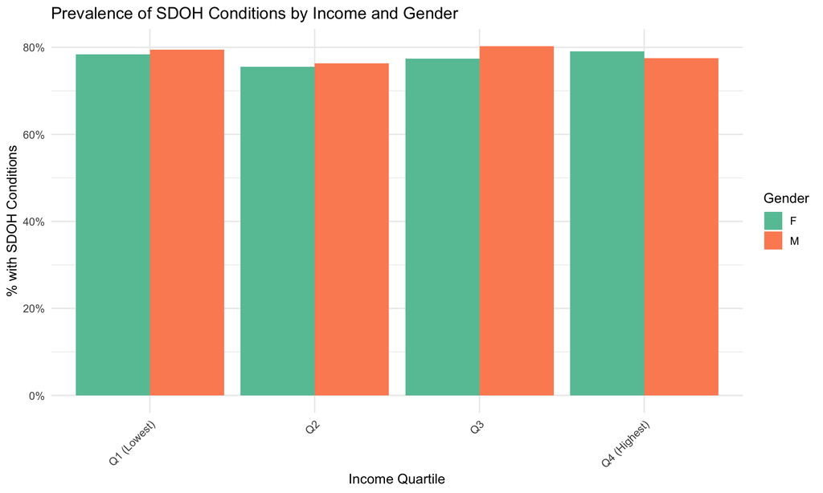

```r
# SDOH by gender and income quartile
patients_analysis <- patients_analysis |>
  mutate(
    income_quartile = cut(
      income,
      breaks = quantile(income, probs = 0:4 / 4, na.rm = TRUE),
      labels = c("Q1 (Lowest)", "Q2", "Q3", "Q4 (Highest)"),
      include.lowest = TRUE
    )
  )

demo_summary <- patients_analysis |>
  group_by(gender, income_quartile, has_sdoh) |>
  summarise(n = n(), .groups = "drop") |>
  group_by(gender, income_quartile) |>
  mutate(pct = n / sum(n) * 100) |>
  filter(has_sdoh)

ggplot(demo_summary, aes(x = income_quartile, y = pct, fill = gender)) +
  geom_col(position = "dodge") +
  labs(
    title = "Prevalence of SDOH Conditions by Income and Gender",
    x = "Income Quartile",
    y = "% with SDOH Conditions",
    fill = "Gender"
  ) +
  scale_y_continuous(labels = label_percent(scale = 1)) +
  scale_fill_brewer(palette = "Set2") +
  theme(axis.text.x = element_text(angle = 45, hjust = 1))
```

## 4.2 Healthcare Utilization Patterns

```r
# Join encounters with patient SDOH status
encounters_analysis <- encounters |>
  left_join(patients_analysis |> select(id, has_sdoh), by = c("patient" = "id"))

# Calculate encounter statistics
encounter_stats <- encounters_analysis |>
  group_by(has_sdoh) |>
  summarise(
    total_encounters = n(),
    patients = n_distinct(patient),
    encounters_per_patient = n() / n_distinct(patient),
    avg_encounter_cost = mean(base_encounter_cost, na.rm = TRUE),
    avg_total_claim = mean(total_claim_cost, na.rm = TRUE)
  )

kable(
  encounter_stats,
  digits = 2,
  col.names = c(
    "Has SDOH",
    "Total Encounters",
    "Patients",
    "Encounters per Patient",
    "Avg Encounter Cost ($)",
    "Avg Total Claim ($)"
  ),
  format.args = list(big.mark = ","),
  caption = "Healthcare Utilization by SDOH Status"
)
```

Healthcare Utilization by SDOH Status

| Has SDOH | Total Encounters | Patients | Encounters per Patient | Avg Encounter Cost ($)\| Avg Total Claim ($) |  |
| --- | --- | --- | --- | --- | --- |
| FALSE | 49,530 | 1,508 | 32.84 | 106.94 | 1,947.25 |
| TRUE | 909,259 | 5,343 | 170.18 | 102.80 | 3,839.81 |

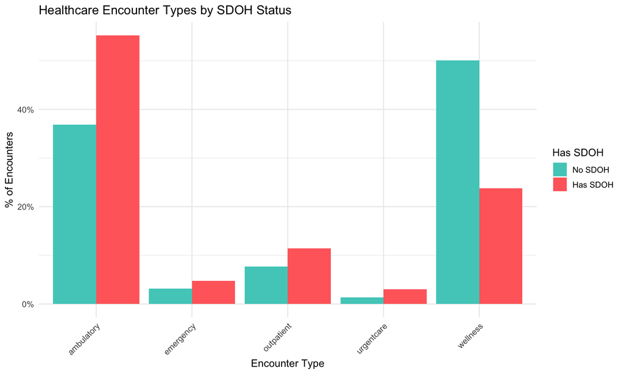

```r
# Encounter types by SDOH status
encounter_type_summary <- encounters_analysis |>
  group_by(has_sdoh, encounterclass) |>
  summarise(n = n(), .groups = "drop") |>
  group_by(has_sdoh) |>
  mutate(pct = n / sum(n) * 100) |>
  filter(
    encounterclass %in%
      c("wellness", "ambulatory", "emergency", "outpatient", "urgentcare")
  )

ggplot(
  encounter_type_summary,
  aes(x = encounterclass, y = pct, fill = has_sdoh)
) +
  geom_col(position = "dodge") +
  labs(
    title = "Healthcare Encounter Types by SDOH Status",
    x = "Encounter Type",
    y = "% of Encounters",
    fill = "Has SDOH"
  ) +
  scale_y_continuous(labels = label_percent(scale = 1)) +
  scale_fill_manual(
    values = c("#4ECDC4", "#FF6B6B"),
    labels = c("No SDOH", "Has SDOH")
  ) +
  theme(axis.text.x = element_text(angle = 45, hjust = 1))
```

## 4.3 Cost Analysis

```r
# Comprehensive cost comparison
cost_comparison <- patients_analysis |>
  mutate(
    out_of_pocket = healthcare_expenses - healthcare_coverage,
    coverage_rate = healthcare_coverage / healthcare_expenses * 100
  ) |>
  group_by(has_sdoh) |>
  summarise(
    n = n(),
    total_expenses = sum(healthcare_expenses, na.rm = TRUE),
    total_coverage = sum(healthcare_coverage, na.rm = TRUE),
    total_out_of_pocket = sum(out_of_pocket, na.rm = TRUE),
    avg_expenses = mean(healthcare_expenses, na.rm = TRUE),
    median_expenses = median(healthcare_expenses, na.rm = TRUE),
    avg_coverage = mean(healthcare_coverage, na.rm = TRUE),
    avg_out_of_pocket = mean(out_of_pocket, na.rm = TRUE)
  )

kable(
  cost_comparison,
  digits = 0,
  col.names = c(
    "Has SDOH",
    "N",
    "Total Expenses",
    "Total Coverage",
    "Total Out-of-Pocket",
    "Avg Expenses",
    "Median Expenses",
    "Avg Coverage",
    "Avg Out-of-Pocket"
  ),
  format.args = list(big.mark = ","),
  caption = "Healthcare Cost Comparison by SDOH Status"
)
```

Healthcare Cost Comparison by SDOH Status

| Has SDOH | N | Total Expenses | Total Coverage | Total Out-of-Pocket | Avg Expenses | Median Expenses | Avg Coverage | Avg Out-of-Pocket |
| --- | --- | --- | --- | --- | --- | --- | --- | --- |
| FALSE | 1,508 | 37,900,643 | 63,657,117 | -25,756,474 | 25,133 | 15,802 | 42,213 | -17,080 |
| TRUE | 5,343 | 1,538,876,591 | 2,481,678,592 | -942,802,001 | 288,017 | 155,638 | 464,473 | -176,456 |

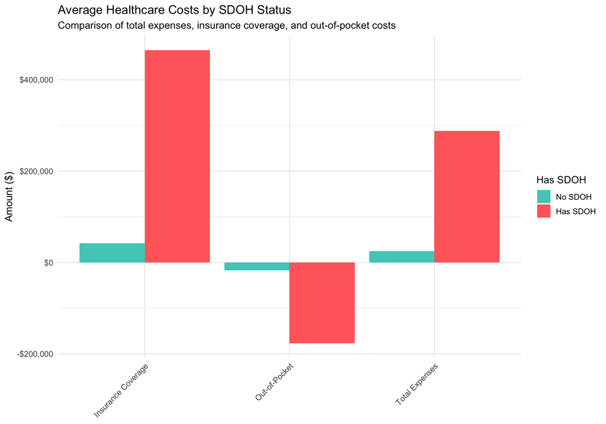

```r
# Visualize cost differences
cost_viz_data <- cost_comparison |>
  select(has_sdoh, avg_expenses, avg_coverage, avg_out_of_pocket) |>
  pivot_longer(
    cols = -has_sdoh,
    names_to = "cost_type",
    values_to = "amount"
  ) |>
  mutate(
    cost_type = recode(
      cost_type,
      "avg_expenses" = "Total Expenses",
      "avg_coverage" = "Insurance Coverage",
      "avg_out_of_pocket" = "Out-of-Pocket"
    )
  )

ggplot(cost_viz_data, aes(x = cost_type, y = amount, fill = has_sdoh)) +
  geom_col(position = "dodge") +
  labs(
    title = "Average Healthcare Costs by SDOH Status",
    subtitle = "Comparison of total expenses, insurance coverage, and out-of-pocket costs",
    x = NULL,
    y = "Amount ($)",
    fill = "Has SDOH"
  ) +
  scale_y_continuous(labels = label_dollar()) +
  scale_fill_manual(
    values = c("#4ECDC4", "#FF6B6B"),
    labels = c("No SDOH", "Has SDOH")
  ) +
  theme(axis.text.x = element_text(angle = 45, hjust = 1))
```

**Key Finding:** Patients with SDOH conditions have **1046%** higher average healthcare expenses.

### Cost by Income Level

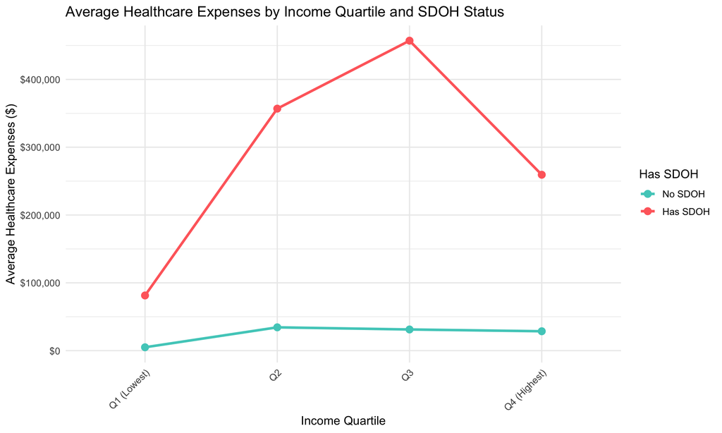

```r
cost_by_income <- patients_analysis |>
  filter(!is.na(income_quartile)) |>
  group_by(income_quartile, has_sdoh) |>
  summarise(
    avg_expenses = mean(healthcare_expenses, na.rm = TRUE),
    avg_out_of_pocket = mean(
      healthcare_expenses - healthcare_coverage,
      na.rm = TRUE
    ),
    .groups = "drop"
  )

ggplot(
  cost_by_income,
  aes(x = income_quartile, y = avg_expenses, color = has_sdoh, group = has_sdoh)
) +
  geom_line(linewidth = 1.2) +
  geom_point(size = 3) +
  labs(
    title = "Average Healthcare Expenses by Income Quartile and SDOH Status",
    x = "Income Quartile",
    y = "Average Healthcare Expenses ($)",
    color = "Has SDOH"
  ) +
  scale_y_continuous(labels = label_dollar()) +
  scale_color_manual(
    values = c("#4ECDC4", "#FF6B6B"),
    labels = c("No SDOH", "Has SDOH")
  ) +
  theme(axis.text.x = element_text(angle = 45, hjust = 1))
```

## 4.4 Chronic Disease Correlation

```r
# Define chronic conditions
chronic_conditions <- c(
  "Essential hypertension (disorder)",
  "Prediabetes (finding)",
  "Chronic pain (finding)",
  "Chronic sinusitis (disorder)",
  "Ischemic heart disease (disorder)",
  "Chronic low back pain (finding)",
  "Severe anxiety (panic) (finding)",
  "Anemia (disorder)"
)

# Find patients with chronic conditions
chronic_patients <- conditions |>
  filter(description %in% chronic_conditions) |>
  distinct(patient) |>
  pull(patient)

# Cross-tabulation
patients_analysis <- patients_analysis |>
  mutate(has_chronic = id %in% chronic_patients)

chronic_cross <- patients_analysis |>
  group_by(has_sdoh, has_chronic) |>
  summarise(n = n(), .groups = "drop") |>
  group_by(has_sdoh) |>
  mutate(pct = n / sum(n) * 100)

kable(
  chronic_cross,
  digits = 1,
  col.names = c(
    "Has SDOH",
    "Has Chronic Condition",
    "N Patients",
    "% of Group"
  ),
  format.args = list(big.mark = ","),
  caption = "Prevalence of Chronic Conditions by SDOH Status"
)
```

Prevalence of Chronic Conditions by SDOH Status

| Has SDOH | Has Chronic Condition | N Patients | % of Group |
| --- | --- | --- | --- |
| FALSE | FALSE | 1,370 | 90.8 |
| FALSE | TRUE | 138 | 9.2 |
| TRUE | FALSE | 810 | 15.2 |
| TRUE | TRUE | 4,533 | 84.8 |

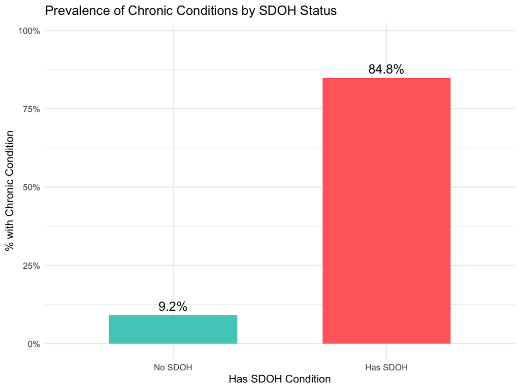

```r
# Calculate odds ratio
chronic_by_sdoh <- patients_analysis |>
  count(has_sdoh, has_chronic) |>
  group_by(has_sdoh) |>
  mutate(pct = n / sum(n) * 100) |>
  filter(has_chronic)

ggplot(chronic_by_sdoh, aes(x = has_sdoh, y = pct, fill = has_sdoh)) +
  geom_col(width = 0.6) +
  geom_text(aes(label = paste0(round(pct, 1), "%")), vjust = -0.5, size = 5) +
  labs(
    title = "Prevalence of Chronic Conditions by SDOH Status",
    x = "Has SDOH Condition",
    y = "% with Chronic Condition"
  ) +
  scale_y_continuous(
    labels = label_percent(scale = 1),
    limits = c(0, max(chronic_by_sdoh$pct) * 1.15)
  ) +
  scale_fill_manual(
    values = c("#4ECDC4", "#FF6B6B"),
    labels = c("No SDOH", "Has SDOH")
  ) +
  scale_x_discrete(labels = c("No SDOH", "Has SDOH")) +
  theme(legend.position = "none")
```

### Specific Chronic Condition Analysis

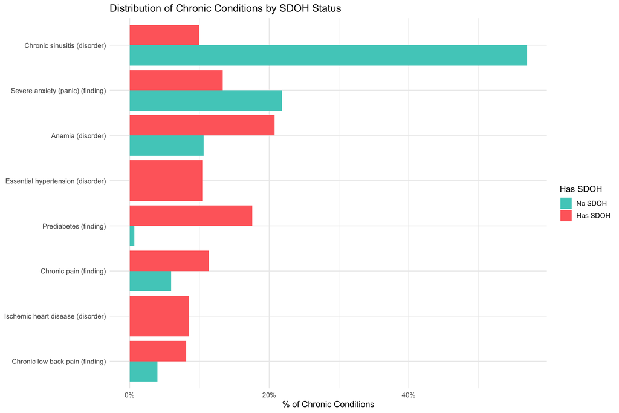

```r
# Top chronic conditions by SDOH status
top_chronic <- conditions |>
  filter(description %in% chronic_conditions) |>
  left_join(
    patients_analysis |> select(id, has_sdoh),
    by = c("patient" = "id")
  ) |>
  group_by(has_sdoh, description) |>
  summarise(n = n(), .groups = "drop") |>
  group_by(has_sdoh) |>
  mutate(pct = n / sum(n) * 100) |>
  arrange(has_sdoh, desc(n))

ggplot(
  top_chronic,
  aes(x = reorder(description, pct), y = pct, fill = has_sdoh)
) +
  geom_col(position = "dodge") +
  coord_flip() +
  labs(
    title = "Distribution of Chronic Conditions by SDOH Status",
    x = NULL,
    y = "% of Chronic Conditions",
    fill = "Has SDOH"
  ) +
  scale_y_continuous(labels = label_percent(scale = 1)) +
  scale_fill_manual(
    values = c("#4ECDC4", "#FF6B6B"),
    labels = c("No SDOH", "Has SDOH")
  )
```

## 4.5 The Compounding Effect

```r
# Count number of SDOH conditions per patient
sdoh_count <- conditions |>
  filter(description %in% sdoh_conditions) |>
  left_join(sdoh_categories, by = c("description" = "condition")) |>
  distinct(patient, category) |>
  count(patient, name = "n_sdoh_categories")

# Add to patient analysis
patients_analysis <- patients_analysis |>
  left_join(sdoh_count, by = c("id" = "patient")) |>
  mutate(
    n_sdoh_categories = replace_na(n_sdoh_categories, 0),
    sdoh_level = case_when(
      n_sdoh_categories == 0 ~ "None",
      n_sdoh_categories == 1 ~ "1 Category",
      n_sdoh_categories == 2 ~ "2 Categories",
      n_sdoh_categories >= 3 ~ "3+ Categories"
    ),
    sdoh_level = factor(
      sdoh_level,
      levels = c("None", "1 Category", "2 Categories", "3+ Categories")
    )
  )

# Cost by number of SDOH factors
compounding_effect <- patients_analysis |>
  group_by(sdoh_level) |>
  summarise(
    n = n(),
    avg_expenses = mean(healthcare_expenses, na.rm = TRUE),
    .groups = "drop"
  )

# Calculate encounters per patient for each group
encounter_counts <- encounters |>
  left_join(
    patients_analysis |> select(id, sdoh_level),
    by = c("patient" = "id")
  ) |>
  group_by(sdoh_level, patient) |>
  summarise(n_encounters = n(), .groups = "drop") |>
  group_by(sdoh_level) |>
  summarise(avg_encounters = mean(n_encounters))

compounding_effect <- compounding_effect |>
  left_join(encounter_counts, by = "sdoh_level")

kable(
  compounding_effect,
  digits = 1,
  col.names = c(
    "SDOH Level",
    "N Patients",
    "Avg Expenses ($)",
    "Avg Encounters"
  ),
  format.args = list(big.mark = ","),
  caption = "Compounding Effect of Multiple SDOH Factors"
)
```

Compounding Effect of Multiple SDOH Factors

| SDOH Level | N Patients | Avg Expenses ($) | Avg Encounters |
| --- | --- | --- | --- |
| None | 1,508 | 25,133.1 | 32.8 |
| 1 Category | 131 | 86,983.7 | 65.9 |
| 2 Categories | 468 | 126,632.2 | 74.4 |
| 3+ Categories | 4,744 | 309,489.4 | 182.5 |

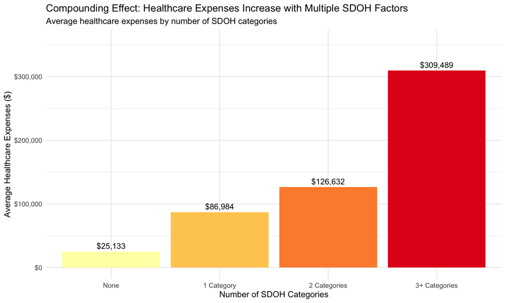

```r
ggplot(
  compounding_effect,
  aes(x = sdoh_level, y = avg_expenses, fill = sdoh_level)
) +
  geom_col() +
  geom_text(
    aes(label = dollar(round(avg_expenses, 0))),
    vjust = -0.5,
    size = 4
  ) +
  labs(
    title = "Compounding Effect: Healthcare Expenses Increase with Multiple SDOH Factors",
    subtitle = "Average healthcare expenses by number of SDOH categories",
    x = "Number of SDOH Categories",
    y = "Average Healthcare Expenses ($)"
  ) +
  scale_y_continuous(
    labels = label_dollar(),
    limits = c(0, max(compounding_effect$avg_expenses) * 1.15)
  ) +
  scale_fill_brewer(palette = "YlOrRd") +
  theme(legend.position = "none")
```

**Key Finding:** Patients with 3 or more SDOH categories have **1131.4%** higher healthcare expenses compared to those with no SDOH factors.

# Key Findings & Discussion

## Clinical and Policy Implications

### For Healthcare Providers

- **Screening Protocols**: Implement systematic screening for SDOH during routine visits
- **Care Coordination**: Develop care pathways that address both medical and social needs
- **Preventive Focus**: Prioritize preventive care for high-risk patients with SDOH factors

### For Policymakers

- **Resource Allocation**: Direct resources toward community-based interventions addressing SDOH
- **Insurance Coverage**: Ensure adequate coverage for services that address social needs
- **Cross-Sector Collaboration**: Foster partnerships between healthcare, social services, and community organizations

### For Healthcare Systems

- **Data Integration**: Incorporate SDOH data into electronic health records
- **Risk Stratification**: Use SDOH information for population health management
- **Value-Based Care**: Design payment models that incentivize SDOH interventions

## Limitations

1. **Causality**: This analysis shows associations but cannot establish causal relationships
2. **Documentation Bias**: SDOH conditions may be under-documented in clinical records
3. **Temporal Relationships**: Limited ability to determine whether SDOH preceded health conditions
4. **Generalizability**: Results are based on synthetic data and may not reflect real-world patterns
5. **Unmeasured Factors**: Other confounding variables not captured in the dataset may influence the relationships observed

# Recommendations

## 1. Implement Universal SDOH Screening

- Develop standardized screening tools for all patients
- Train clinical staff on trauma-informed approaches to collecting social history
- Integrate screening into routine workflows

## 2. Establish Community Partnerships

- Create referral networks with social service organizations
- Develop care navigation programs to connect patients with resources
- Implement community health worker programs

## 3. Develop Targeted Interventions

- Design programs specifically for high-risk groups (multiple SDOH factors)
- Focus on stress reduction and social connection interventions
- Address economic instability through employment and financial counseling programs

## 4. Enhance Data Systems

- Improve documentation of SDOH in clinical records
- Develop analytics capabilities to track SDOH impact over time
- Use predictive modeling to identify at-risk patients early

## 5. Advocate for Policy Change

- Support policies that address upstream social factors
- Advocate for reimbursement for SDOH screening and intervention
- Promote cross-sector funding for integrated health and social services

## 6. Conduct Further Research

- Longitudinal studies examining SDOH trajectories and health outcomes
- Intervention trials testing effectiveness of specific SDOH programs
- Cost-effectiveness analyses of SDOH interventions
- Qualitative research to understand patient experiences and preferences

## Conclusion

This analysis demonstrates the profound impact of social determinants of health on healthcare costs and utilization. The “hidden costs” of SDOH are substantial—not only in direct healthcare expenses but also in the human toll of preventable chronic disease and health disparities. Addressing SDOH is not just a matter of social justice but also a pragmatic strategy for improving population health and controlling healthcare costs.

Healthcare systems that invest in identifying and addressing social risk factors stand to benefit from improved patient outcomes, reduced acute care utilization, and more equitable care delivery. The path forward requires commitment from clinicians, administrators, policymakers, and communities to create a healthcare system that recognizes and responds to the full spectrum of factors influencing health.